# Part II - Customer Bike Usage Patterns and Trends

## by James Hansen

## Investigation Overview

In this investigation, I wanted to focus on the bike usage pattern over the course of a day, week and month.

I also included some interesting details uncovered during exploration on customer age and gender.

## Dataset Overview

This data set includes information about individual bike rides made in a bike-sharing system covering the greater San Francisco Bay area. There are 183,412 bike trips, including information on trip duration, start/end times and locations, as well as member gender, birth year and customer type.

After preliminary wrangling, the final dataset had 174,952 entries with 19 features.

## Distribution of Bike Trip Duration

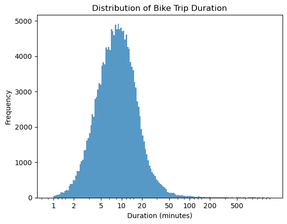

## Average Bike Usage per Day

Bike usage differs depending on whether the day falls in a work week or a weekend. Bike trips tend to higher from Monday - Friday while Saturday and Sunday bike usage decreases by 42%.

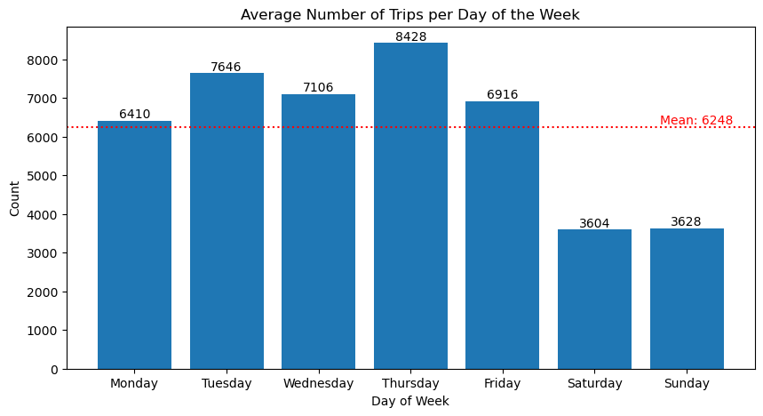

## Bike Usage Trends over a month

By observing the total number of bikes trips per day, a clear pattern emerges. A sharp decline over 2-3 days, then a rise and peak over 3-4 days. This follows the Monday - Sunday week, a typical working cycle.

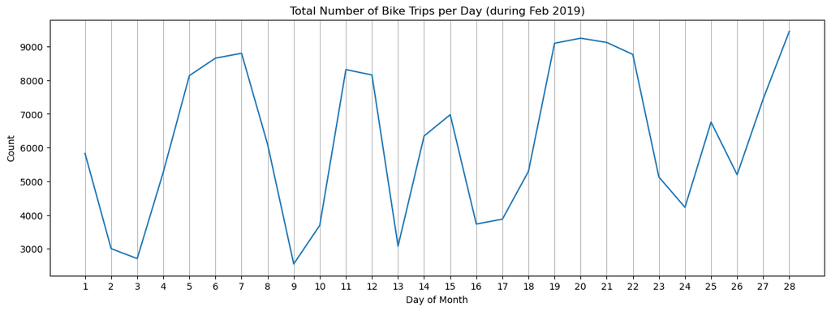

## Bike Usage over a 24 hour cycle

A less granular look at the data unveils a new cyclical pattern. Not only do bike usages vary per day but per hour. During the work week,the usage is bimodal with spikes in the morning and late afternoon; there is also a mini peak around lunch. During the weekend, bike usage is lower indicated by the lower maximal peak but also it is unimodal, peaking around lunch.

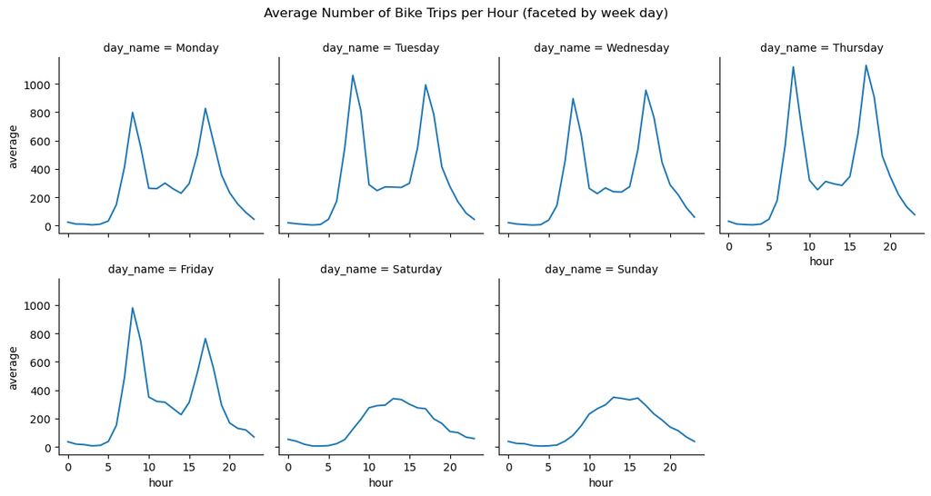

## Member age by Categorical Features

The box plots indicate a few interesting trends. Firstly, at least 50% of the user are below the ages of 35 years regardless of categorical differences. Secondly, most users are below the age of 60 (near retirement age).

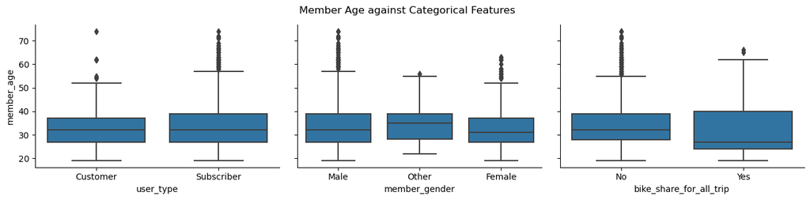

## Distribution of Member Gender

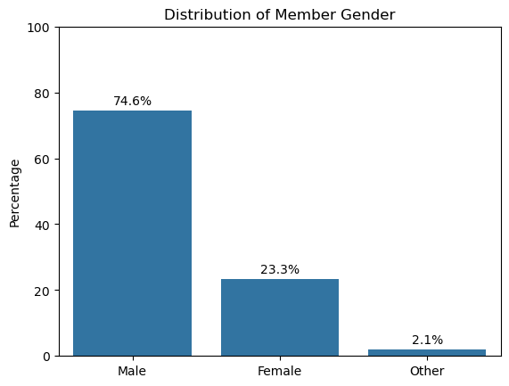

## Conclusion

The bike usage cases informs us that the bikes are used probably by working individuals and most of the clientele are young to middle age males. This can help the company in logistics and operations by ensuring there are enough bikes to suit demand and improve profitability as they can target advertisement and sales towards these demographics.